# Pathologie de la main

JcB - RESURAL

31/12/2015

# 1 Analyse CCOM

Analyse faite le 28/12/2015 pour évaluer l’introduction du DP au CCOM.

- Période analysée: 17/12/2015, 02/01/2016
- Date d’envoi du premier RPU: 06/10/2015
- Date de point: 02/01/2016
- Nombre de RPU créés: 2458
- Date de début d’envoi de RPU avec DP renseigné: 17/12/2015
- Taux de complétude moyen du DP: 68 %

Evolution du taux de completude du diagnostic principal (DP)

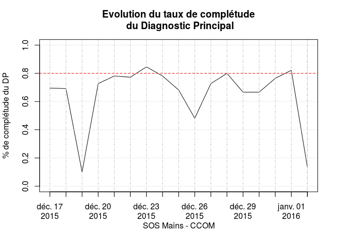

**Un taux de complétude régulièrement supérieur à 80% est nécessaire pour tirer des conclusions valides.**

## 1.1 Caractéristiques de la population

### 1.1.1 Age

Tous les RPU du CCOM

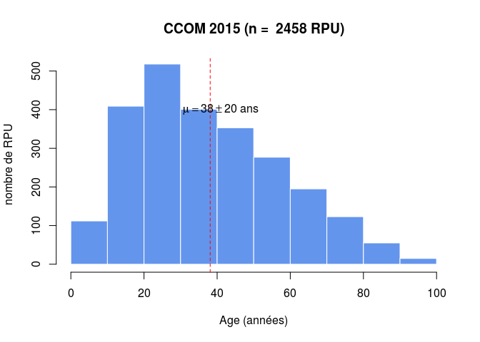

### 1.1.2 Sexe

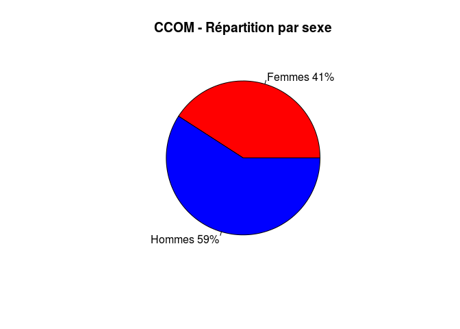

En moyenne, les femmes sont plus agées que les hommes:

- age moyen des femmes: 41.3 ans.
- age moyen des hommes: 35.9 ans.
- la différence est statistiquement significative (p = 1.636810410^{-10})

### 1.1.3 Répartition des codes CIM 10

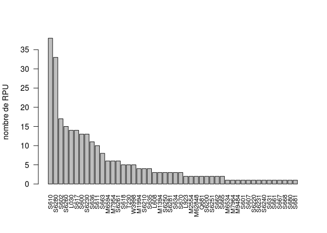

## 1.2 Code CIM10 mains

Les codes CIM10 sont dans le dossier FEDORU:

|  | CODE | Freq | LIBELLE |
| --- | --- | --- | --- |
| 18 | S610 | 38 | Plaie ouverte de(s) doigt(s) (sans lésion de l’ongle) |
| 32 | S6280 | 33 | Fracture fermée de parties autres et non précisées du poignet et de la main |
| 16 | S602 | 17 | Contusion d’autres parties du poignet et de la main |
| 30 | S6260 | 15 | Fracture fermée d’un autre doigt |
| 1 | L030 | 14 | Phlegmon des doigts et des orteils |
| 20 | S617 | 14 | Plaies ouvertes multiples du poignet et de la main |
| 14 | S600 | 13 | Contusion de(s) doigt(s) sans lésion de l’ongle |
| 25 | S6230 | 13 | Fracture fermée d’un autre os du métacarpe |
| 37 | S636 | 11 | Entorse et foulure de doigt(s) |
| 19 | S611 | 10 | Plaie ouverte de(s) doigt(s) avec lésion de l’ongle |
| 40 | S663 | 8 | Lésion traumatique du muscle et du tendon extenseurs d’un autre doigt au niveau du poignet et de la main |
| 9 | M6594 | 6 | Synovite et ténosynovite, sans précision - Main |
| 10 | M7954 | 6 | Corps étranger résiduel dans un tissu mou - Main |
| 31 | S6261 | 6 | Fracture ouverte d’un autre doigt |
| 21 | S618 | 5 | Plaie ouverte d’autres parties du poignet et de la main |
| 47 | T230 | 5 | Brûlure du poignet et de la main, degré non précisé |
| 48 | W3998 | 5 | Projection de feu d’artifice, lieu sans précision |
| 5 | M1994 | 4 | Arthrose, sans précision - Articulations de la main |
| 23 | S6210 | 4 | Fracture fermée d’autre(s) os du carpe |
| 36 | S635 | 4 | Entorse et foulure du poignet |
| 2 | L608 | 3 | Autres maladies des ongles |
| 4 | M1394 | 3 | Arthrite, sans précision - Articulations de la main |
| 28 | S6250 | 3 | Fracture fermée du pouce |
| 33 | S6281 | 3 | Fracture ouverte de parties autres et non précisées du poignet et de la main |
| 35 | S634 | 3 | Rupture traumatique de ligaments du doigt au niveau des articulations métacarpo-phalangienne et interphalangienne |
| 44 | S670 | 3 | Écrasement du pouce et d’autre(s) doigt(s) |
| 3 | L923 | 2 | Granulome cutané et sous-cutané dû à la présence d’un corps étranger |
| 6 | M2554 | 2 | Douleur articulaire - Articulations de la main |
| 7 | M62848 | 2 | Autres atteintes musculaires précisées, Main |
| 13 | Q681 | 2 | Anomalie morphologique congénitale de la main |
| 22 | S6200 | 2 | Fracture fermée de l’os scaphoïde de la main |
| 29 | S6251 | 2 | Fracture ouverte du pouce |
| 39 | S662 | 2 | Lésion traumatique du muscle et du tendon extenseurs du pouce au niveau du poignet et de la main |
| 41 | S665 | 2 | Lésion traumatique de muscles et de tendons intrinsèques d’un autre doigt au niveau du poignet et de la main |
| 8 | M6534 | 1 | Doigt “à ressort” - Main |
| 11 | M7964 | 1 | Douleur au niveau d’un membre - Main |
| 12 | M9484 | 1 | Autres affections précisées du cartilage - Main |
| 15 | S601 | 1 | Contusion de(s) doigt(s) avec lésion de l’ongle |
| 17 | S607 | 1 | Lésions traumatiques superficielles multiples du poignet et de la main |
| 24 | S6220 | 1 | Fracture fermée du premier métacarpien |
| 26 | S6231 | 1 | Fracture ouverte d’un autre os du métacarpe |
| 27 | S6240 | 1 | Fractures fermées multiples des métacarpiens |
| 34 | S631 | 1 | Luxation du doigt |
| 38 | S661 | 1 | Lésion traumatique du muscle et du tendon fléchisseurs d’un autre doigt au niveau du poignet et de la main |
| 42 | S667 | 1 | Lésion traumatique de multiples muscles et tendons extenseurs au niveau du poignet et de la main |
| 43 | S668 | 1 | Lésion traumatique d’autres muscles et tendons au niveau du poignet et de la main |
| 45 | S680 | 1 | Amputation traumatique du pouce (complète) (partielle) |
| 46 | S681 | 1 | Amputation traumatique d’un autre doigt (complète) (partielle) |

## 1.3 Lesions liées aux pétards

Sélectionne toutes les lignes avec le code W39:

- Nombre de lésions dues aux pétards: 5

## 1.4 Nombre de passages par mois

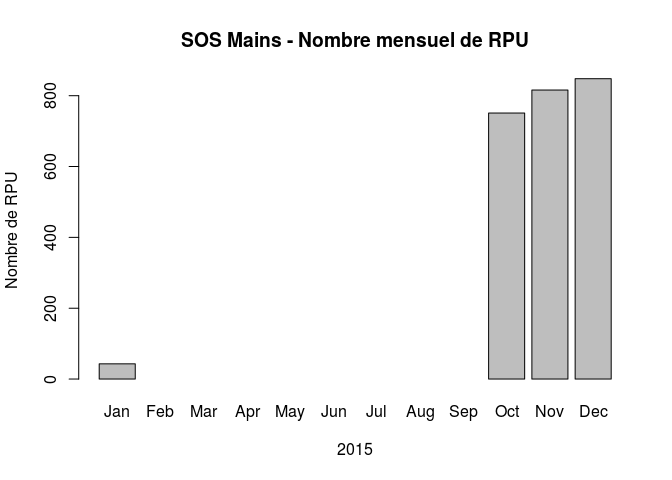

## 1.5 Nombre de passages par semaine

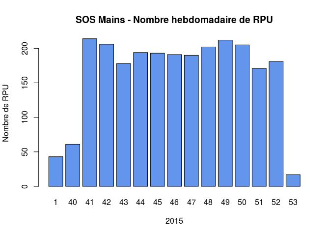

## 1.6 Nombre de passages par jour de semaine

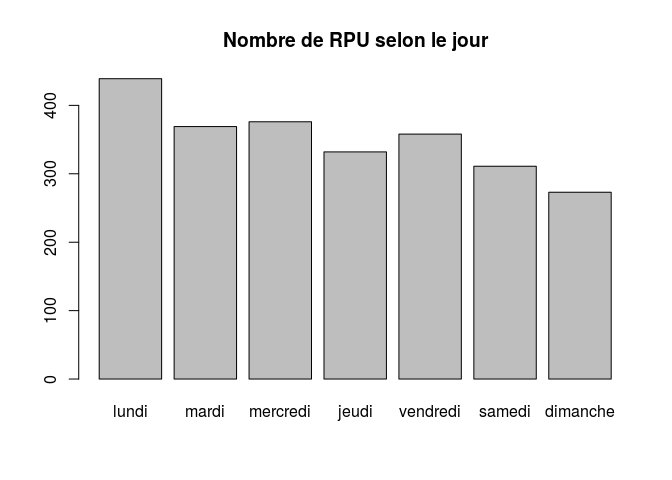

## 1.7 Nombre de passages par jour

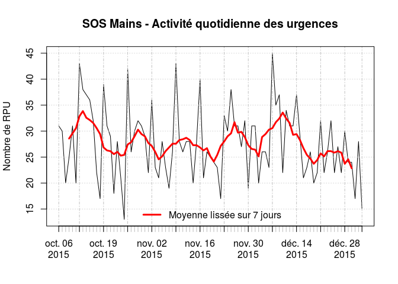

## 1.8 Horaires de passage

L’histogramme des horaires de passage est assez semblable à celui des services d’urgence polyvalents. Cependant l’aspect bimodal parait plus marqué, avec une fréquentation plus forte en début de matinée et d’après-midi (messages de prévention ?).

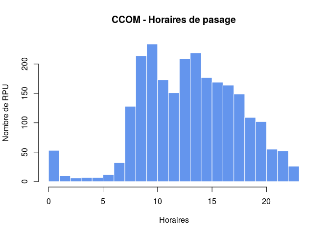

## 1.9 Durées de passage

L’heure de sortie n’est différente de l’heure d’entrée que dans 7% des cas. Lorsque l’heure de sortie diffère de l’heure d’entrée, la durée de passage est égale à une minute dans 75% des cas… Il y a donc un problème avec l’heure de sortie.

```
## [1] 0
```

```
##     Min.  1st Qu.   Median     Mean  3rd Qu.     Max.
##    0.000    0.000    0.000    3.941    0.000 1260.000
```

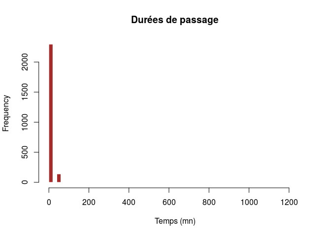

## 1.10 Origine des patients

### 1.10.1 Par département

#### 1.10.1.1 En nombre:

```
cp2
  17   24   27   30   33   42   49   50   56   59   66   69   81   86   36
   1    1    1    1    1    1    1    1    1    1    1    1    1    1    2
  44   52   54   55   75   76   45   70   83   88   92   94   90   99   57
   2    2    2    2    2    2    3    3    3    3    3    4    5   11   53
  68   67
  69 2273
```

#### 1.10.1.2 En porcentage:

```
cp2
    17     24     27     30     33     42     49     50     56     59
 0.041  0.041  0.041  0.041  0.041  0.041  0.041  0.041  0.041  0.041
    66     69     81     86     36     44     52     54     55     75
 0.041  0.041  0.041  0.041  0.081  0.081  0.081  0.081  0.081  0.081
    76     45     70     83     88     92     94     90     99     57
 0.081  0.122  0.122  0.122  0.122  0.122  0.163  0.203  0.448  2.156
    68     67
 2.807 92.474
```

Cartographie

[output not shown]

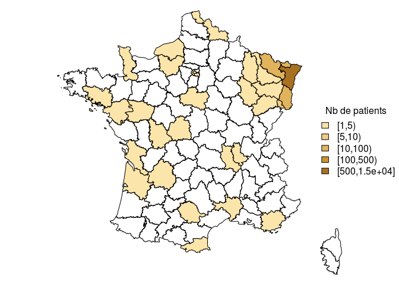

### 1.10.2 en Alsace

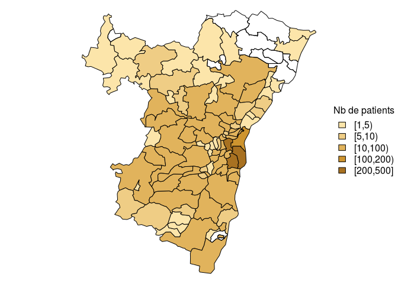

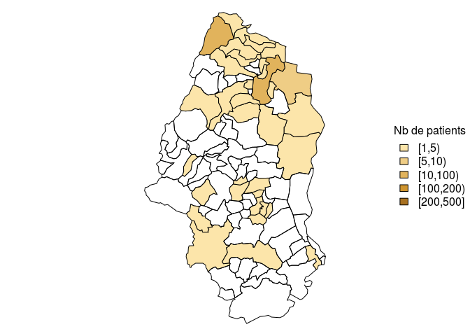